# Ten tests, no effect: an introduction to multiple testing

Author

Jake Bowers — EGAP Learning Days, Santiago de Chile

Published

July 30, 2026

## The situation

Imagine we evaluate a social program in 100 households: half, assigned at random, receive the program. Because the program could affect many dimensions of life, we measure ten outcome variables: income, employment, school attendance, health, trust in neighbors, civic participation, savings, perceived security, consumption, and life satisfaction. At the end of the study we run one hypothesis test per outcome and report which ones produced a p-value below 0.05.

Each individual test promises to err rarely: if the program has no effect on that outcome, the probability of declaring a “significant effect” by pure chance is 5%. This document asks a different question: if the program has no effect on **any** of the ten outcomes, what is the probability that **at least one** of the ten tests declares an effect? Intuition says “5%, same as before.” The correct answer is about 40%.

To see this, we will build a world where we know for certain that the program does nothing — because we generate the data ourselves — and then look at what the tests produce in that world.

## A world where the program does nothing

Each household has, for each variable, two **potential outcomes**: the outcome it would show if it received the program, $y(1)$, and the outcome it would show if it did not, $y(0)$. “The program does nothing” has an exact translation into this language: $y(1) = y(0)$ for every household and every outcome. We build that world directly:

```r
set.seed(20260751) ## master seed: fixes Y0 and the first experiment's assignment

N <- 100 ## households
K <- 10 ## outcome variables

outcome_names <- c(
  "income", "employment", "attendance", "health", "trust",
  "participation", "savings", "security", "consumption", "satisfaction"
)

## Potential outcomes: Y0 under control, Y1 under treatment.
## "The program does nothing" is literally Y1 = Y0,
## for every household and every outcome.
Y0 <- matrix(rnorm(N * K), nrow = N, dimnames = list(NULL, outcome_names))
Y1 <- Y0
```

The null hypothesis — the program changes nothing for anyone — is true by construction, for all ten outcomes at once. Now we assign the treatment at random (50 treated households, 50 control) and observe, for each household, the potential outcome that corresponds to its assignment: $Y_{obs} = Z \cdot y(1) + (1 - Z) \cdot y(0)$.

```r
Z <- sample(rep(c(0, 1), N / 2)) ## completely randomized assignment

## We observe Y1 in the treated and Y0 in the controls.
## Because Y1 = Y0, the assignment changes nothing about what we see.
Yobs <- Z * Y1 + (1 - Z) * Y0
dat <- data.frame(Z = factor(Z), Yobs)
```

## One experiment, ten tests

We do what the evaluation team would do: one test per outcome. We use two different procedures to show that the problem does not come from any particular test. `oneway_test()` from the `coin` package compares means using the permutation distribution: it re-shuffles the assignment 5000 times and asks how extreme the observed statistic is among those re-shuffles. `lm_robust()` from the `estimatr` package estimates the difference in means with HC2 standard errors and a normal approximation. Both are justified by the random assignment — the first uses it directly, the second approximates it.

```r
p_oneway <- sapply(outcome_names, function(v) {
  pvalue(oneway_test(reformulate("Z", v),
    data = dat,
    distribution = approximate(nresample = 5000)
  ))
})

p_lm <- sapply(outcome_names, function(v) {
  est <- tidy(lm_robust(reformulate("Z", v), data = dat))
  est$p.value[est$term == "Z1"]
})

table1 <- data.frame(
  outcome = outcome_names,
  p_oneway = round(p_oneway, 3),
  p_lm_robust = round(p_lm, 3),
  significant = ifelse(p_lm <= 0.05, "*", "")
)
kable(table1, row.names = FALSE)
```

| outcome | p_oneway | p_lm_robust | significant |
| --- | --- | --- | --- |
| income | 0.619 | 0.613 |  |
| employment | 0.953 | 0.950 |  |
| attendance | 0.256 | 0.274 |  |
| health | 0.008 | 0.010 | * |
| trust | 0.503 | 0.500 |  |
| participation | 0.534 | 0.543 |  |
| savings | 0.749 | 0.755 |  |
| security | 0.156 | 0.157 |  |
| consumption | 0.463 | 0.452 |  |
| satisfaction | 0.570 | 0.573 |  |

Look at the `health` row: p = 0.01 with both tests.[^1] If this were a real study, the report would say “the program improved health (p < 0.05)” — and perhaps the executive summary would mention only that result. But we know the program did nothing: we built `health` with $y(1) = y(0)$ for every household. The two tests agree almost exactly, because the problem is not in the test. It is in how many questions we asked the data.

## The family-wise error rate (FWER)

First in words. When we run a single test at significance level $\alpha = 0.05$, the 5% is the probability of a false positive **in that test**. When we run ten tests, the set of ten is a **family**, and the question that matters to the reader of the report is: what is the probability that the whole family produces **at least one** false positive? That probability is called the **family-wise error rate** (FWER).

Now with a little algebra. Suppose the $K$ tests were independent and all the null hypotheses were true. Each test “gets it right” (does not reject) with probability $1 - \alpha$: with $\alpha = 0.05$, it gets it right 95% of the time. With what probability do the first two get it right at the same time? Because they are independent, we multiply: $0.95 \times 0.95 \approx 0.90$. Each additional test multiplies by 0.95 again, so after $K$ tests the probability that **all** of them get it right is $(1 - \alpha)^K$ — a number that shrinks with every test we add. And “at least one false positive” is exactly the opposite of “all get it right”, so its probability is one minus that:

$$\text{FWER} = 1 - (1 - \alpha)^K.$$

With $\alpha = 0.05$ and $K = 10$, that gives $1 - 0.95^{10}$ = 0.401. Back to words: a team that evaluates ten outcomes of a program with no effect has about a 40% chance of “discovering” something. With twenty outcomes, the probability reaches 0.64. The curve grows fast:

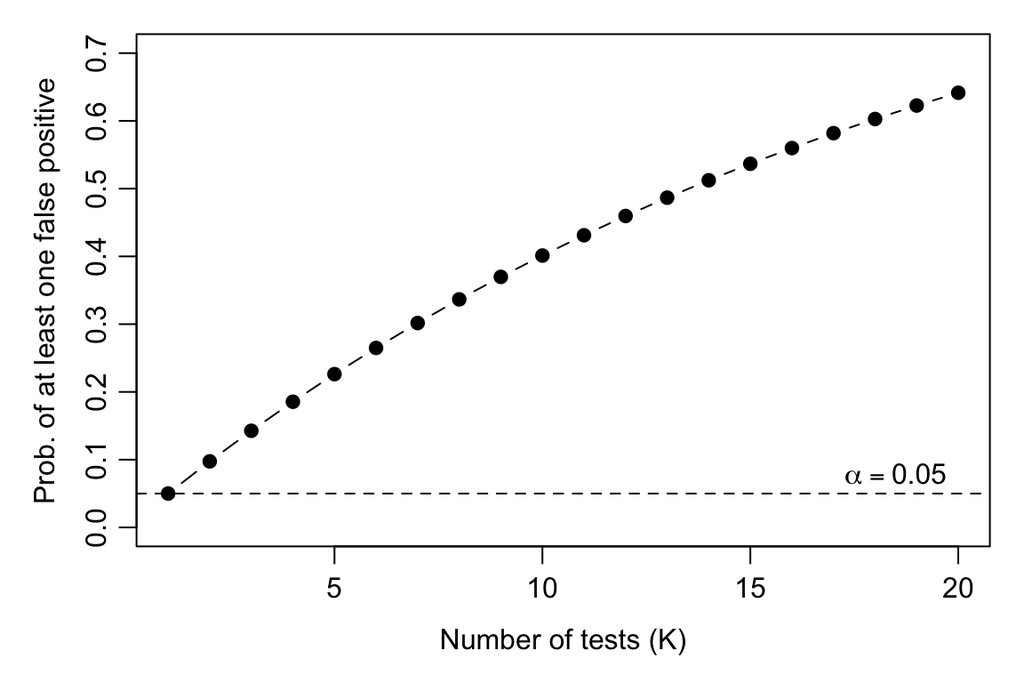

In a real experiment the outcomes are usually correlated with each other, and then the formula $1 - (1-\alpha)^K$ is only an approximation. That is why we do not stop at the algebra: we simulate.

## The simulation: we repeat the experiment 1000 times

In our constructed world, the only source of randomness is the treatment assignment — exactly the source of randomness that justifies the two tests. So we keep the potential outcomes `Y0` and `Y1` fixed and re-draw the assignment $B = 1000$ times, applying the same observation equation each time. In each repetition we run the ten tests with each procedure and store the p-values.

```r
run_experiment <- function() {
  ## Re-draw the assignment and observe again; Y0 and Y1 stay fixed.
  Z_new <- sample(rep(c(0, 1), N / 2))
  d <- data.frame(Z = factor(Z_new), Z_new * Y1 + (1 - Z_new) * Y0)
  p_ow <- sapply(outcome_names, function(v) {
    pvalue(oneway_test(reformulate("Z", v),
      data = d,
      distribution = approximate(nresample = 5000)
    ))
  })
  p_lm <- sapply(outcome_names, function(v) {
    est <- tidy(lm_robust(reformulate("Z", v), data = d))
    est$p.value[est$term == "Z1"]
  })
  rbind(oneway = p_ow, lm_robust = p_lm)
}

set.seed(20260731) ## simulation seed
B <- 1000
sims <- replicate(B, run_experiment()) ## dimensions: 2 procedures x K x B
```

Before looking at the FWER, let us verify that each individual test keeps its promise. For each outcome, we compute the proportion of the 1000 repetitions in which that test rejected with $p \leq 0.05$:

```r
reject_ow <- rowMeans(sims["oneway", , ] <= 0.05)
reject_lm <- rowMeans(sims["lm_robust", , ] <= 0.05)
kable(
  data.frame(
    outcome = outcome_names,
    oneway_test = round(reject_ow, 3),
    lm_robust = round(reject_lm, 3)
  ),
  row.names = FALSE
)
```

| outcome | oneway_test | lm_robust |
| --- | --- | --- |
| income | 0.047 | 0.048 |
| employment | 0.054 | 0.054 |
| attendance | 0.047 | 0.045 |
| health | 0.039 | 0.041 |
| trust | 0.048 | 0.047 |
| participation | 0.054 | 0.054 |
| savings | 0.051 | 0.052 |
| security | 0.063 | 0.063 |
| consumption | 0.044 | 0.046 |
| satisfaction | 0.054 | 0.052 |

Each number estimates a proportion with $B = 1000$ repetitions, so it carries a simulation error (Monte Carlo standard error) of $\sqrt{0.05 \times 0.95 / 1000} \approx 0.007$. All the rates are where they should be: near 5%. Test by test, nothing is broken.

Now the family question: in what proportion of the 1000 repetitions did **at least one** of the ten tests reject?

```r
fwer_ow <- mean(apply(sims["oneway", , ] <= 0.05, 2, any))
fwer_lm <- mean(apply(sims["lm_robust", , ] <= 0.05, 2, any))
c(oneway_test = fwer_ow, lm_robust = fwer_lm)
```

```
oneway_test   lm_robust
      0.398       0.399
```

The estimated FWER is 0.4 with `oneway_test()` and 0.4 with `lm_robust()` (Monte Carlo standard error $\approx 0.015$), consistent with the theoretical value of 0.401 for independent tests. This is the contrast that matters: **every row of the previous table says 5%, and yet the family errs 40% of the time.** In four of every ten evaluations of a program that does nothing, the report can say “we found a significant effect” without anyone having cheated.

## The correction: one line of code

Multiple-comparison procedures adjust the p-values so that the 5% promise applies to the whole family and not to each test separately (Bretz et al. 2011). The simplest is Bonferroni: compare each p-value with $\alpha / K$ instead of $\alpha$. The Holm procedure does the same thing step by step and rejects at least as much as Bonferroni, so we use Holm. In R it is one line: `p.adjust(p, method = "holm")`.

We repeat the FWER calculation, now adjusting the ten p-values within each repetition before asking whether any falls below 0.05:

```r
fwer_holm_ow <- mean(apply(sims["oneway", , ], 2, function(p) {
  any(p.adjust(p, method = "holm") <= 0.05)
}))
fwer_holm_lm <- mean(apply(sims["lm_robust", , ], 2, function(p) {
  any(p.adjust(p, method = "holm") <= 0.05)
}))
c(oneway_test = fwer_holm_ow, lm_robust = fwer_holm_lm)
```

```
oneway_test   lm_robust
      0.036       0.036
```

With the Holm adjustment, the estimated FWER drops to 0.036 and 0.036 — below the promised 5%. The correction is not free: demanding smaller p-values means less power to detect real effects when they exist. That cost is a reason to declare few primary hypotheses, or to group outcomes into indices, rather than test everything that was measured. When the family is very large, controlling a different rate — the expected proportion of false discoveries among the rejections (FDR) — can be a more reasonable target than the FWER (Benjamini and Hochberg 1995).

## What does this have to do with transparency?

The 40% calculation assumes something that almost never holds: that the reader sees all ten tests. If the report mentions only `health`, the reader cannot know that it was one test among ten, and the p-value of 0.01 looks like strong evidence. Nor does the problem require bad faith: it is enough for the analysis decisions — which outcomes to test, how to define them, which subgroups to examine — to be made after seeing the data (Gelman and Loken 2013).

The pre-analysis plan answers exactly this. Declaring in advance which hypotheses are primary, how each outcome is defined, and which multiple-testing correction will be applied makes the size of the family visible. The FWER guarantee is a promise about the complete family; it only means something to a reader who can see the complete family. That is what registering the design delivers.

## References

Benjamini, Yoav, and Yosef Hochberg. 1995. “Controlling the false discovery rate: a practical and powerful approach to multiple testing.” *Journal of the Royal Statistical Society* 57 (1): 289–300. http://www.jstor.org/stable/2346101.

Bretz, Frank, Torsten Hothorn, and Peter Westfall. 2011. *Multiple comparisons using R*. CRC Press. https://doi.org/10.2307/1266041.

Gelman, Andrew, and Eric Loken. 2013. “The garden of forking paths: Why multiple comparisons can be a problem, even when there is no “fishing expedition” or “p-hacking” and the research hypothesis was posited ahead of time.” https://sites.stat.columbia.edu/gelman/research/unpublished/p_hacking.pdf.

## Footnotes

[^1]: We chose the master seed from among several so that this first experiment would fall inside the ~40% of experiments that produce at least one false positive. The simulation below shows how often that happens; it is not a rare case.